# Buan 4310 Project 1

2023-10-19

The return of the Infinity Stones to their original timelines by Steve Rogers appears to have caused ripples through the timeline. With Tony Stark now in an alternate reality, Stark Enterprises faces new challenges. The company has expanded into financial services but lacks Tony’s analytical brilliance for this complex domain.

To aid their entry into this competitive market, Stark Enterprises hopes to build a predictive model that identifies customers prone to financial risk. The model would enable proactive management of credit exposures.

```r
#loading library
library(caret)
library(Tplyr)
library(tidyverse)
library(dplyr)
library(ROSE)
library(rpart)
```

```r
library(rpart.plot)
library(forecast)
#Import the data set
credit_33 <- read_csv("credit_fa2023_33.csv")
```

```
## ──────────────────────────────────────────────────────── Delimiter: "," chr
## (12): NAME_CONTRACT_TYPE, CODE_GENDER, FLAG_OWN_CAR, FLAG_OWN_REALTY, NA... dbl
## (56): ...1, SK_ID_CURR, TARGET, CNT_CHILDREN, AMT_INCOME_TOTAL, AMT_CRED...
```

```r
head(credit_33)
```

```
## # A tibble: 6 × 68
##     ...1 SK_ID_CURR TARGET NAME_CONTRACT_TYPE CODE_GENDER FLAG_OWN_CAR
##    <dbl>      <dbl>  <dbl> <chr>              <chr>       <chr>
## 1 203109     335466      0 Cash loans         M           Y
## 2  88503     202756      0 Cash loans         M           N
## 3 181349     310179      0 Cash loans         F           N
## 4 158480     283724      0 Cash loans         F           N
## 5 244471     382965      0 Cash loans         F           Y
## 6 138723     260855      0 Cash loans         F           N
## # ℹ 62 more variables: FLAG_OWN_REALTY <chr>, CNT_CHILDREN <dbl>,
## #   AMT_INCOME_TOTAL <dbl>, AMT_CREDIT <dbl>, AMT_ANNUITY <dbl>,
## #   AMT_GOODS_PRICE <dbl>, NAME_TYPE_SUITE <chr>, NAME_INCOME_TYPE <chr>,
## #   NAME_EDUCATION_TYPE <chr>, NAME_FAMILY_STATUS <chr>,
## #   NAME_HOUSING_TYPE <chr>, DAYS_BIRTH <dbl>, DAYS_EMPLOYED <dbl>,
## #   DAYS_REGISTRATION <dbl>, DAYS_ID_PUBLISH <dbl>, OWN_CAR_AGE <dbl>,
## #   FLAG_MOBIL <dbl>, FLAG_EMP_PHONE <dbl>, FLAG_WORK_PHONE <dbl>, …
```

In selecting variables for predicting customer credit risk, we have concentrated on both primary and secondary factors that could potentially influence a client’s ability to repay a loan.

Primary Variables: AMT_INCOME_TOTAL: A client’s income is a fundamental metric, as it directly impacts their capacity to meet financial obligations. Higher income may imply a better capability to repay loans. AMT_CREDIT: The loan amount is significant because larger loans might carry higher default risks due to the increased financial burden on the client. AMT_ANNUITY: The periodic loan payment amount can affect a client’s budget and their ability to maintain regular payments. DAYS_EMPLOYED: Employment duration can reflect job stability, which in turn suggests consistent income and a lower risk of default. NAME_INCOME_TYPE: The income source can illuminate the reliability of income; for example, a permanent employee may have a more stable income compared to a freelancer. NAME_EDUCATION_TYPE: Educational attainment can indicate a client’s financial literacy and economic stability, potentially affecting their risk profile. DAYS_BIRTH: Age can serve as a surrogate for financial experience, with older clients potentially having more stability and financial savvy.

Secondary Variables: CNT_FAM_MEMBERS: The number of family members may influence a client’s financial responsibilities and hence their repayment capability. NAME_CONTRACT_TYPE: Different loan types may exhibit distinct default patterns due to the terms of the loan or the nature of the borrower who chooses a particular loan type. REGION_RATING_CLIENT & REGION_RATING_CLIENT_W_CITY: Ratings by region can suggest economic conditions, with certain regions potentially correlating with higher or lower risk of default. DAYS_LAST_PHONE_CHANGE: This could indicate personal stability; frequent changes might suggest instability, which could correlate with financial risk.

Data Transformations: Income-Credit Ratio (AMT_INCOME_TOTAL/AMT_CREDIT): This ratio may highlight if a client’s income is adequate when compared to the loan amount, providing insight into potential financial strain. Annuity-Income Ratio (AMT_ANNUITY/AMT_INCOME_TOTAL): This measures the loan’s annuity as a percentage of income, helping to understand the loan’s impact on the client’s finances.

These selected variables and transformations are anticipated to collectively provide a nuanced view of a client’s financial situation and help to predict the low-high risk of the customer.

```r
#Data transformation
credit_33$Income_credit_ratio <- credit_33$AMT_INCOME_TOTAL / credit_33$AMT_CREDIT

credit_33$Annuity_income_ratio <- credit_33$AMT_ANNUITY / credit_33$AMT_INCOME_TOTAL
```

```r
#Select variables for the data set
credit_33 <- credit_33[ ,c(3,4,9:11,14,15,18,19,30:32,42,69,70)]
names(credit_33)
```

```
##  [1] "TARGET"                      "NAME_CONTRACT_TYPE"
##  [3] "AMT_INCOME_TOTAL"            "AMT_CREDIT"
##  [5] "AMT_ANNUITY"                 "NAME_INCOME_TYPE"
##  [7] "NAME_EDUCATION_TYPE"         "DAYS_BIRTH"
##  [9] "DAYS_EMPLOYED"               "CNT_FAM_MEMBERS"
## [11] "REGION_RATING_CLIENT"        "REGION_RATING_CLIENT_W_CITY"
## [13] "DAYS_LAST_PHONE_CHANGE"      "Income_credit_ratio"
## [15] "Annuity_income_ratio"
```

```r
str(credit_33)
```

```
## tibble [30,000 × 15] (S3: tbl_df/tbl/data.frame)
##  $ TARGET                     : num [1:30000] 0 0 0 0 0 0 0 1 0 0 ...
##  $ NAME_CONTRACT_TYPE         : chr [1:30000] "Cash loans" "Cash loans" "Cash loans" "Cash loans" ...
##  $ AMT_INCOME_TOTAL           : num [1:30000] 61200 225000 202500 90000 112500 ...
##  $ AMT_CREDIT                 : num [1:30000] 808650 1467612 508496 959598 132444 ...
##  $ AMT_ANNUITY                : num [1:30000] 24602 59904 38146 28058 14391 ...
##  $ NAME_INCOME_TYPE           : chr [1:30000] "Pensioner" "State servant" "State servant" "State servant" ...
##  $ NAME_EDUCATION_TYPE        : chr [1:30000] "Secondary / secondary special" "Higher education" "Secondary / secondary special" "Secondary / secondary special" ...
##  $ DAYS_BIRTH                 : num [1:30000] -23509 -23340 -15634 -14070 -11581 ...
##  $ DAYS_EMPLOYED              : num [1:30000] 365243 -204 -1510 -6650 -3301 ...
##  $ CNT_FAM_MEMBERS            : num [1:30000] 4 2 1 5 2 2 3 2 3 2 ...
##  $ REGION_RATING_CLIENT       : num [1:30000] 2 2 2 2 2 2 3 2 2 2 ...
##  $ REGION_RATING_CLIENT_W_CITY: num [1:30000] 2 2 2 2 2 2 3 2 2 2 ...
##  $ DAYS_LAST_PHONE_CHANGE     : num [1:30000] -1034 -2307 -1442 -1110 -2631 ...
##  $ Income_credit_ratio        : num [1:30000] 0.0757 0.1533 0.3982 0.0938 0.8494 ...
##  $ Annuity_income_ratio       : num [1:30000] 0.402 0.266 0.188 0.312 0.128 ...
```

When performing statistical operations that involve character variables, the underlying mechanism often involves an implicit conversion of these characters to factors. To optimize performance and ensure precise control over the results, it is advisable to explicitly convert character variables to factors before using them in such functions. This proactive approach prevents unexpected outcomes and enhances the efficiency of the computations.

```r
credit_33$NAME_INCOME_TYPE <- as.factor(credit_33$NAME_INCOME_TYPE)
credit_33$NAME_EDUCATION_TYPE <- as.factor(credit_33$NAME_EDUCATION_TYPE)
credit_33$NAME_CONTRACT_TYPE <- as.factor(credit_33$NAME_CONTRACT_TYPE)
credit_33$TARGET <- as.factor(credit_33$TARGET)
levels(credit_33$TARGET) <- c("Low", "High")
```

```r
str(credit_33)
```

```
## tibble [30,000 × 15] (S3: tbl_df/tbl/data.frame)
##  $ TARGET                     : Factor w/ 2 levels "Low","High": 1 1 1 1 1 1 1 2 1 1 ...
##  $ NAME_CONTRACT_TYPE         : Factor w/ 2 levels "Cash loans","Revolving loans": 1 1 1 1 1 1 1 1 1 1 ...
##  $ AMT_INCOME_TOTAL           : num [1:30000] 61200 225000 202500 90000 112500 ...
##  $ AMT_CREDIT                 : num [1:30000] 808650 1467612 508496 959598 132444 ...
##  $ AMT_ANNUITY                : num [1:30000] 24602 59904 38146 28058 14391 ...
##  $ NAME_INCOME_TYPE           : Factor w/ 6 levels "Commercial associate",..: 2 3 3 3 1 6 6 6 3 3 ...
##  $ NAME_EDUCATION_TYPE        : Factor w/ 5 levels "Academic degree",..: 5 2 5 5 2 5 5 3 2 5 ...
##  $ DAYS_BIRTH                 : num [1:30000] -23509 -23340 -15634 -14070 -11581 ...
##  $ DAYS_EMPLOYED              : num [1:30000] 365243 -204 -1510 -6650 -3301 ...
##  $ CNT_FAM_MEMBERS            : num [1:30000] 4 2 1 5 2 2 3 2 3 2 ...
##  $ REGION_RATING_CLIENT       : num [1:30000] 2 2 2 2 2 2 3 2 2 2 ...
##  $ REGION_RATING_CLIENT_W_CITY: num [1:30000] 2 2 2 2 2 2 3 2 2 2 ...
##  $ DAYS_LAST_PHONE_CHANGE     : num [1:30000] -1034 -2307 -1442 -1110 -2631 ...
##  $ Income_credit_ratio        : num [1:30000] 0.0757 0.1533 0.3982 0.0938 0.8494 ...
##  $ Annuity_income_ratio       : num [1:30000] 0.402 0.266 0.188 0.312 0.128 ...
```

We split the data into training and validation set to avoid overfitting if we use only one data set to predict

```r
#Traning-Validation split
set.seed(567)

train_index <- sample(1:nrow(credit_33), 0.7 * nrow(credit_33))
valid_index <- setdiff(1:nrow(credit_33), train_index)

train_df <- credit_33[train_index, ]
valid_df <- credit_33[valid_index, ]

nrow(train_df)
```

```
## [1] 21000
```

```r
nrow(valid_df)
```

```
## [1] 9000
```

```r
names(train_df)
```

```
##  [1] "TARGET"                      "NAME_CONTRACT_TYPE"
##  [3] "AMT_INCOME_TOTAL"            "AMT_CREDIT"
##  [5] "AMT_ANNUITY"                 "NAME_INCOME_TYPE"
##  [7] "NAME_EDUCATION_TYPE"         "DAYS_BIRTH"
##  [9] "DAYS_EMPLOYED"               "CNT_FAM_MEMBERS"
## [11] "REGION_RATING_CLIENT"        "REGION_RATING_CLIENT_W_CITY"
## [13] "DAYS_LAST_PHONE_CHANGE"      "Income_credit_ratio"
## [15] "Annuity_income_ratio"
```

```r
str(train_df)
```

```
## tibble [21,000 × 15] (S3: tbl_df/tbl/data.frame)
##  $ TARGET                     : Factor w/ 2 levels "Low","High": 1 1 1 1 1 1 1 1 1 2 ...
##  $ NAME_CONTRACT_TYPE         : Factor w/ 2 levels "Cash loans","Revolving loans": 1 1 1 1 1 1 1 1 2 1 ...
##  $ AMT_INCOME_TOTAL           : num [1:21000] 225000 157500 180000 180000 315000 ...
##  $ AMT_CREDIT                 : num [1:21000] 1078200 946764 1078200 432567 2013840 ...
##  $ AMT_ANNUITY                : num [1:21000] 28570 37678 31653 22779 55377 ...
##  $ NAME_INCOME_TYPE           : Factor w/ 6 levels "Commercial associate",..: 6 1 1 6 3 1 6 2 6 1 ...
##  $ NAME_EDUCATION_TYPE        : Factor w/ 5 levels "Academic degree",..: 3 2 5 5 2 5 5 5 5 3 ...
##  $ DAYS_BIRTH                 : num [1:21000] -9287 -20600 -11497 -19465 -15112 ...
##  $ DAYS_EMPLOYED              : num [1:21000] -137 -1661 -3497 -3516 -4171 ...
##  $ CNT_FAM_MEMBERS            : num [1:21000] 1 2 4 3 2 2 2 2 3 2 ...
##  $ REGION_RATING_CLIENT       : num [1:21000] 2 2 3 2 2 1 2 2 3 1 ...
##  $ REGION_RATING_CLIENT_W_CITY: num [1:21000] 2 2 3 2 2 1 2 2 2 1 ...
##  $ DAYS_LAST_PHONE_CHANGE     : num [1:21000] -1071 -1706 -1500 -263 -1409 ...
##  $ Income_credit_ratio        : num [1:21000] 0.209 0.166 0.167 0.416 0.156 ...
##  $ Annuity_income_ratio       : num [1:21000] 0.127 0.239 0.176 0.127 0.176 ...
```

The decision to balance our data set originates from the initial observation that the vast majority of cases (represented by the value 0) are low. Because of the prevalence of the majority class, such an imbalance can bias our prediction model toward prediction low. This imbalance can result in a model with good accuracy for the majority class but poor prediction ability for the minority class (in this case, high), which is our primary concern.

We use balancing approaches to ensure that our model does not develop a natural bias toward predicting low. By creating a data set with more evenly distributed examples of low and hihg, we give our model a greater chance of learning the distinctive characteristics of both classes. This process of balancing is necessary for constructing a robust model that is sensitive to credit risk nuances and can properly anticipate possible defaults, both of which are critical for successful risk management in lending institutions.

```r
#weighted training df
train_df_rose <- ROSE(TARGET ~ .,
                      data = train_df, seed = 567)$data
table(train_df_rose$TARGET)
```

```
##
##   Low  High
## 10484 10513
```

```r
#remove missing value of validation set
valid_df <- na.omit(valid_df)
```

We normalize values to bring them into a common scale, making it easier to compare and analyze data. Normalization also helps to reduce the impact of outliers and improve the accuracy and stability of statistical models.

```r
#Normalisation
train_norm <- train_df_rose
valid_norm <- valid_df

norm_values <- preProcess(train_df_rose[, -c(1)],method = c("center",
                                                       "scale"))
str(norm_values)
```

```
## List of 21
##  $ dim              : int [1:2] 20997 14
##  $ bc               : NULL
##  $ yj               : NULL
##  $ et               : NULL
##  $ invHyperbolicSine: NULL
##  $ mean             : Named num [1:11] 165683 579636 27041 -15572 53875 ...
##   ..- attr(*, "names")= chr [1:11] "AMT_INCOME_TOTAL" "AMT_CREDIT" "AMT_ANNUITY" "DAYS_BIRTH" ...
##  $ std              : Named num [1:11] 100354 428180 15198 4820 147917 ...
##   ..- attr(*, "names")= chr [1:11] "AMT_INCOME_TOTAL" "AMT_CREDIT" "AMT_ANNUITY" "DAYS_BIRTH" ...
##  $ ranges           : NULL
##  $ rotation         : NULL
##  $ method           :List of 3
##   ..$ center: chr [1:11] "AMT_INCOME_TOTAL" "AMT_CREDIT" "AMT_ANNUITY" "DAYS_BIRTH" ...
##   ..$ scale : chr [1:11] "AMT_INCOME_TOTAL" "AMT_CREDIT" "AMT_ANNUITY" "DAYS_BIRTH" ...
##   ..$ ignore: chr [1:3] "NAME_CONTRACT_TYPE" "NAME_INCOME_TYPE" "NAME_EDUCATION_TYPE"
##  $ thresh           : num 0.95
##  $ pcaComp          : NULL
##  $ numComp          : NULL
##  $ ica              : NULL
##  $ wildcards        :List of 2
##   ..$ PCA: chr(0)
##   ..$ ICA: chr(0)
##  $ k                : num 5
##  $ knnSummary       :function (x, ...)
##  $ bagImp           : NULL
##  $ median           : NULL
##  $ data             : NULL
##  $ rangeBounds      : num [1:2] 0 1
##  - attr(*, "class")= chr "preProcess"
```

```r
train_norm[, -c(1)] <- predict(norm_values,
                                train_df_rose[, -c(1)])

head(train_norm)
```

```
##   TARGET NAME_CONTRACT_TYPE AMT_INCOME_TOTAL  AMT_CREDIT AMT_ANNUITY
## 1    Low         Cash loans       -1.0818111 -0.38548830 -0.84551865
## 2    Low         Cash loans       -0.4294294  0.93361969 -0.70795682
## 3    Low         Cash loans       -0.7664424 -0.02875306 -0.50967920
## 4    Low         Cash loans        1.8292472 -0.44291997 -0.35766928
## 5    Low         Cash loans       -1.0605899 -0.86579806  0.05806789
## 6    Low    Revolving loans        0.5621991  1.49737860  1.98689612
##       NAME_INCOME_TYPE           NAME_EDUCATION_TYPE DAYS_BIRTH DAYS_EMPLOYED
## 1 Commercial associate Secondary / secondary special  1.5762164    -1.1820603
## 2 Commercial associate              Higher education  0.1750867    -0.4370872
## 3              Working Secondary / secondary special  0.9276477     0.3975009
## 4              Working Secondary / secondary special -0.8660275     1.0449209
## 5            Pensioner Secondary / secondary special -0.1929214     1.3951377
## 6 Commercial associate              Higher education  1.9682745    -0.5723398
##   CNT_FAM_MEMBERS REGION_RATING_CLIENT REGION_RATING_CLIENT_W_CITY
## 1       0.1827888           0.32219678                -0.353203919
## 2       0.2594776          -0.16336942                 0.006576076
## 3      -1.4422362           0.78537062                 1.114466383
## 4      -0.6144960          -0.03831888                 0.725199452
## 5      -1.8178795           1.34081382                 1.573274087
## 6      -1.1433735          -0.01628174                -0.175219427
##   DAYS_LAST_PHONE_CHANGE Income_credit_ratio Annuity_income_ratio
## 1             0.75611864          -0.8726999            1.2738876
## 2            -0.69809795           0.3555940           -1.1689230
## 3            -0.17373707          -0.2588496            0.2731584
## 4             0.06373262           0.8082173           -0.5421059
## 5            -0.75810202          -0.8770886            1.1222028
## 6             0.32711472          -0.3039248            0.4683895
```

```r
valid_norm[, -c(1)] <- predict(norm_values,
                              valid_df[, -c(1)])

head(valid_norm)
```

```
## # A tibble: 6 × 15
##   TARGET NAME_CONTRACT_TYPE AMT_INCOME_TOTAL AMT_CREDIT AMT_ANNUITY
##   <fct>  <fct>                         <dbl>      <dbl>       <dbl>
## 1 Low    Cash loans                    0.591     2.07        2.16
## 2 Low    Cash loans                    0.143     1.73        0.560
## 3 Low    Cash loans                    0.143    -0.166      -0.170
## 4 Low    Cash loans                    0.143     1.17        0.261
## 5 High   Cash loans                   -0.485     0.748      -0.0391
## 6 Low    Cash loans                   -0.754    -0.0808     -0.0350
## # ℹ 10 more variables: NAME_INCOME_TYPE <fct>, NAME_EDUCATION_TYPE <fct>,
## #   DAYS_BIRTH <dbl>, DAYS_EMPLOYED <dbl>, CNT_FAM_MEMBERS <dbl>,
## #   REGION_RATING_CLIENT <dbl>, REGION_RATING_CLIENT_W_CITY <dbl>,
## #   DAYS_LAST_PHONE_CHANGE <dbl>, Income_credit_ratio <dbl>,
## #   Annuity_income_ratio <dbl>
```

```r
#Import test set
credit_test <- read_csv("credit_test_fa2023_33.csv")
```

```
## ──────────────────────────────────────────────────────── Delimiter: "," chr
## (12): NAME_CONTRACT_TYPE, CODE_GENDER, FLAG_OWN_CAR, FLAG_OWN_REALTY, NA... dbl
## (55): ...1, SK_ID_CURR, CNT_CHILDREN, AMT_INCOME_TOTAL, AMT_CREDIT, AMT_...
```

```r
#Data tranformation
credit_test$Income_credit_ratio <- credit_test$AMT_INCOME_TOTAL / credit_test$AMT_CREDIT

credit_test$Annuity_income_ratio <- credit_test$AMT_ANNUITY / credit_test$AMT_INCOME_TOTAL
head(credit_test)
```

```
## # A tibble: 5 × 69
##    ...1 SK_ID_CURR NAME_CONTRACT_TYPE CODE_GENDER FLAG_OWN_CAR FLAG_OWN_REALTY
##   <dbl>      <dbl> <chr>              <chr>       <chr>        <chr>
## 1     1     153235 Cash loans         F           N            Y
## 2     2     385110 Cash loans         M           Y            N
## 3     3     175617 Cash loans         M           Y            Y
## 4     4     164682 Cash loans         F           Y            Y
## 5     5     162022 Cash loans         M           N            Y
## # ℹ 63 more variables: CNT_CHILDREN <dbl>, AMT_INCOME_TOTAL <dbl>,
## #   AMT_CREDIT <dbl>, AMT_ANNUITY <dbl>, AMT_GOODS_PRICE <dbl>,
## #   NAME_TYPE_SUITE <chr>, NAME_INCOME_TYPE <chr>, NAME_EDUCATION_TYPE <chr>,
## #   NAME_FAMILY_STATUS <chr>, NAME_HOUSING_TYPE <chr>, DAYS_BIRTH <dbl>,
## #   DAYS_EMPLOYED <dbl>, DAYS_REGISTRATION <dbl>, DAYS_ID_PUBLISH <dbl>,
## #   OWN_CAR_AGE <dbl>, FLAG_MOBIL <dbl>, FLAG_EMP_PHONE <dbl>,
## #   FLAG_WORK_PHONE <dbl>, FLAG_CONT_MOBILE <dbl>, FLAG_PHONE <dbl>, …
```

```r
#Select variables
credit_test <- credit_test[ ,c(3,8:10,13,14,17,18,29:31,41,68,69)]
names(credit_test)
```

```
##  [1] "NAME_CONTRACT_TYPE"          "AMT_INCOME_TOTAL"
##  [3] "AMT_CREDIT"                  "AMT_ANNUITY"
##  [5] "NAME_INCOME_TYPE"            "NAME_EDUCATION_TYPE"
##  [7] "DAYS_BIRTH"                  "DAYS_EMPLOYED"
##  [9] "CNT_FAM_MEMBERS"             "REGION_RATING_CLIENT"
## [11] "REGION_RATING_CLIENT_W_CITY" "DAYS_LAST_PHONE_CHANGE"
## [13] "Income_credit_ratio"         "Annuity_income_ratio"
```

```r
#Set as factor
credit_test$NAME_INCOME_TYPE <- as.factor(credit_test$NAME_INCOME_TYPE)
credit_test$NAME_EDUCATION_TYPE <- as.factor(credit_test$NAME_EDUCATION_TYPE)
credit_test$NAME_CONTRACT_TYPE <- as.factor(credit_test$NAME_CONTRACT_TYPE)
```

```r
credit_test_norm <- predict(norm_values, credit_test)
credit_test_norm
```

```
## # A tibble: 5 × 14
##   NAME_CONTRACT_TYPE AMT_INCOME_TOTAL AMT_CREDIT AMT_ANNUITY NAME_INCOME_TYPE
##   <fct>                         <dbl>      <dbl>       <dbl> <fct>
## 1 Cash loans                    0.143     -0.346     -0.322  Pensioner
## 2 Cash loans                    1.49      -0.513     -0.0557 Working
## 3 Cash loans                    2.83      -0.400     -0.399  Working
## 4 Cash loans                   -0.440     -0.112     -0.0877 Pensioner
## 5 Cash loans                   -0.306     -0.747      0.258  Working
## # ℹ 9 more variables: NAME_EDUCATION_TYPE <fct>, DAYS_BIRTH <dbl>,
## #   DAYS_EMPLOYED <dbl>, CNT_FAM_MEMBERS <dbl>, REGION_RATING_CLIENT <dbl>,
## #   REGION_RATING_CLIENT_W_CITY <dbl>, DAYS_LAST_PHONE_CHANGE <dbl>,
## #   Income_credit_ratio <dbl>, Annuity_income_ratio <dbl>
```

We create KNN model and Classification Tree model to compare and see which model will be the best for predict new client finacial risk.

```r
#KNN model set k = 3
knn_model_k3 <- caret::knn3(TARGET ~ .,
                            data = train_norm, k = 3)
knn_model_k3
```

```
## 3-nearest neighbor model
## Training set outcome distribution:
##
##   Low  High
## 10484 10513
```

```r
#Predict training set
knn_pred_k3_train <- predict(knn_model_k3,
                             newdata = train_norm[, -c(1)],
                             type = "class")
head(knn_pred_k3_train)
```

```
## [1] Low Low Low Low Low Low
## Levels: Low High
```

```r
confusionMatrix(knn_pred_k3_train, as.factor(train_norm[, 1, drop = TRUE]), positive = "High")
```

```
## Confusion Matrix and Statistics
##
##           Reference
## Prediction  Low High
##       Low  8042 1846
##       High 2442 8667
##
##                Accuracy : 0.7958
##                  95% CI : (0.7903, 0.8012)
##     No Information Rate : 0.5007
##     P-Value [Acc > NIR] : < 2.2e-16
##
##                   Kappa : 0.5915
##
##  Mcnemar's Test P-Value : < 2.2e-16
##
##             Sensitivity : 0.8244
##             Specificity : 0.7671
##          Pos Pred Value : 0.7802
##          Neg Pred Value : 0.8133
##              Prevalence : 0.5007
##          Detection Rate : 0.4128
##    Detection Prevalence : 0.5291
##       Balanced Accuracy : 0.7957
##
##        'Positive' Class : High
##
```

```r
#Predict validation set
knn_pred_k3_valid <- predict(knn_model_k3,

                             newdata = valid_norm[, -c(1)],

                             type = "class")

head(knn_pred_k3_valid)
```

```
## [1] Low  High High Low  Low  High
## Levels: Low High
```

```r
confusionMatrix(knn_pred_k3_valid, as.factor(valid_norm[, 1, drop = TRUE]), positive = "High")
```

```
## Confusion Matrix and Statistics
##
##           Reference
## Prediction  Low High
##       Low  3944  723
##       High 3351  982
##
##                Accuracy : 0.5473
##                  95% CI : (0.537, 0.5577)
##     No Information Rate : 0.8106
##     P-Value [Acc > NIR] : 1
##
##                   Kappa : 0.0733
##
##  Mcnemar's Test P-Value : <2e-16
##
##             Sensitivity : 0.5760
##             Specificity : 0.5406
##          Pos Pred Value : 0.2266
##          Neg Pred Value : 0.8451
##              Prevalence : 0.1894
##          Detection Rate : 0.1091
##    Detection Prevalence : 0.4814
##       Balanced Accuracy : 0.5583
##
##        'Positive' Class : High
##
```

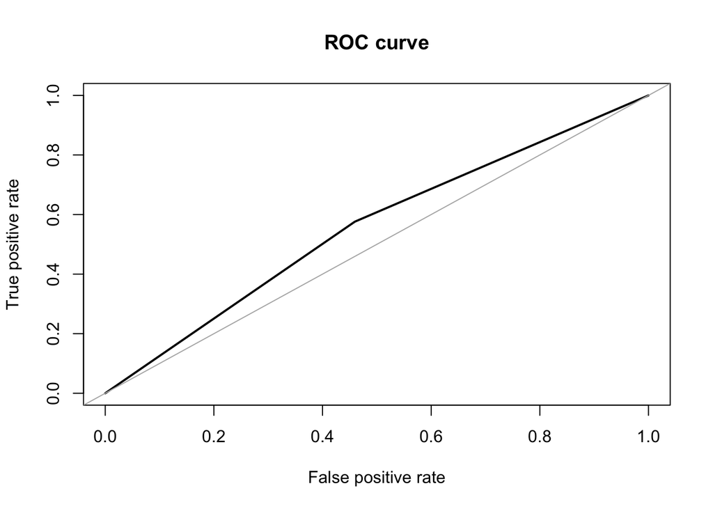

```
## Area under the curve (AUC): 0.558
```

```r
ROSE::roc.curve(valid_norm$TARGET, knn_pred_k3_valid)
```

```r
#KNN model set k = 5
knn_model_k5 <- caret::knn3(TARGET ~ .,
                            data = train_norm, k = 5)
knn_model_k5
```

```
## 5-nearest neighbor model
## Training set outcome distribution:
##
##   Low  High
## 10484 10513
```

```r
#Predict training set
knn_pred_k5_train <- predict(knn_model_k5,
                             newdata = train_norm[, -c(1)],
                             type = "class")
head(knn_pred_k5_train)
```

```
## [1] High Low  Low  Low  Low  Low
## Levels: Low High
```

```r
confusionMatrix(knn_pred_k5_train, as.factor(train_norm[, 1, drop = TRUE]), positive = "High")
```

```
## Confusion Matrix and Statistics
##
##           Reference
## Prediction  Low High
##       Low  7444 2269
##       High 3040 8244
##
##                Accuracy : 0.7472
##                  95% CI : (0.7412, 0.753)
##     No Information Rate : 0.5007
##     P-Value [Acc > NIR] : < 2.2e-16
##
##                   Kappa : 0.4943
##
##  Mcnemar's Test P-Value : < 2.2e-16
##
##             Sensitivity : 0.7842
##             Specificity : 0.7100
##          Pos Pred Value : 0.7306
##          Neg Pred Value : 0.7664
##              Prevalence : 0.5007
##          Detection Rate : 0.3926
##    Detection Prevalence : 0.5374
##       Balanced Accuracy : 0.7471
##
##        'Positive' Class : High
##
```

```r
#Predict validation set
knn_pred_k5_valid <- predict(knn_model_k5,

                             newdata = valid_norm[, -c(1)],

                             type = "class")

head(knn_pred_k5_valid)
```

```
## [1] Low  High High Low  Low  High
## Levels: Low High
```

```r
confusionMatrix(knn_pred_k5_valid, as.factor(valid_norm[, 1, drop = TRUE]), positive = "High")
```

```
## Confusion Matrix and Statistics
##
##           Reference
## Prediction  Low High
##       Low  3886  672
##       High 3409 1033
##
##                Accuracy : 0.5466
##                  95% CI : (0.5362, 0.5569)
##     No Information Rate : 0.8106
##     P-Value [Acc > NIR] : 1
##
##                   Kappa : 0.0858
##
##  Mcnemar's Test P-Value : <2e-16
##
##             Sensitivity : 0.6059
##             Specificity : 0.5327
##          Pos Pred Value : 0.2326
##          Neg Pred Value : 0.8526
##              Prevalence : 0.1894
##          Detection Rate : 0.1148
##    Detection Prevalence : 0.4936
##       Balanced Accuracy : 0.5693
##
##        'Positive' Class : High
##
```

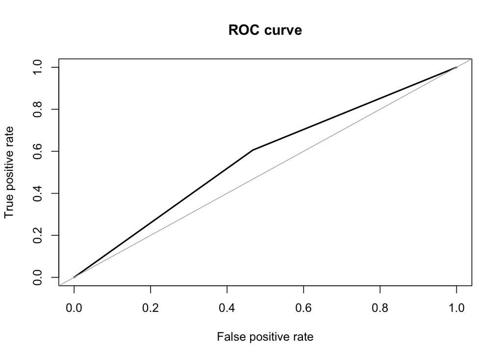

```
## Area under the curve (AUC): 0.569
```

```r
ROSE::roc.curve(valid_norm$TARGET, knn_pred_k5_valid)
```

```r
#KNN model set k = 7
knn_model_k7 <- caret::knn3(TARGET ~ .,
                            data = train_norm, k = 7)
knn_model_k7
```

```
## 7-nearest neighbor model
## Training set outcome distribution:
##
##   Low  High
## 10484 10513
```

```r
#Predict training set
knn_pred_k7_train <- predict(knn_model_k7,
                             newdata = train_norm[, -c(1)],
                             type = "class")
head(knn_pred_k7_train)
```

```
## [1] High Low  High Low  Low  Low
## Levels: Low High
```

```r
confusionMatrix(knn_pred_k7_train, as.factor(train_norm[, 1, drop = TRUE]), positive = "High")
```

```
## Confusion Matrix and Statistics
##
##           Reference
## Prediction  Low High
##       Low  7114 2420
##       High 3370 8093
##
##                Accuracy : 0.7242
##                  95% CI : (0.7181, 0.7303)
##     No Information Rate : 0.5007
##     P-Value [Acc > NIR] : < 2.2e-16
##
##                   Kappa : 0.4484
##
##  Mcnemar's Test P-Value : < 2.2e-16
##
##             Sensitivity : 0.7698
##             Specificity : 0.6786
##          Pos Pred Value : 0.7060
##          Neg Pred Value : 0.7462
##              Prevalence : 0.5007
##          Detection Rate : 0.3854
##    Detection Prevalence : 0.5459
##       Balanced Accuracy : 0.7242
##
##        'Positive' Class : High
##
```

```r
# Predict validation set
knn_pred_k7_valid <- predict(knn_model_k7,

                             newdata = valid_norm[, -c(1)],

                             type = "class")

head(knn_pred_k7_valid)
```

```
## [1] Low  High High Low  Low  High
## Levels: Low High
```

```r
confusionMatrix(knn_pred_k7_valid, as.factor(valid_norm[, 1, drop = TRUE]), positive = "High")
```

```
## Confusion Matrix and Statistics
##
##           Reference
## Prediction  Low High
##       Low  3894  655
##       High 3401 1050
##
##                Accuracy : 0.5493
##                  95% CI : (0.539, 0.5597)
##     No Information Rate : 0.8106
##     P-Value [Acc > NIR] : 1
##
##                   Kappa : 0.0925
##
##  Mcnemar's Test P-Value : <2e-16
##
##             Sensitivity : 0.6158
##             Specificity : 0.5338
##          Pos Pred Value : 0.2359
##          Neg Pred Value : 0.8560
##              Prevalence : 0.1894
##          Detection Rate : 0.1167
##    Detection Prevalence : 0.4946
##       Balanced Accuracy : 0.5748
##
##        'Positive' Class : High
##
```

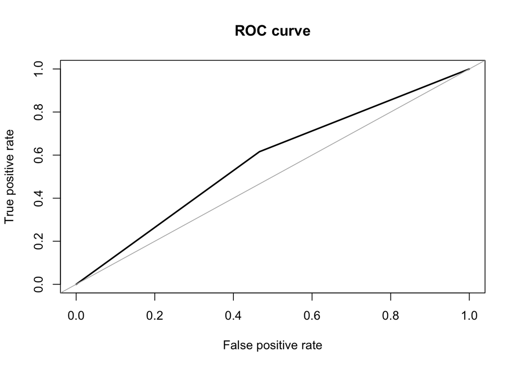

```
## Area under the curve (AUC): 0.575
```

```r
ROSE::roc.curve(valid_norm$TARGET, knn_pred_k7_valid)
```

Looking at the models, we can see that for all KNN models, there is a drop in accuracy from the training set to the validation set. This is indicative of overfitting, as the models are performing significantly better on the data, they were trained on compared to new, unseen data.

```r
names(train_df_rose)
```

```
##  [1] "TARGET"                      "NAME_CONTRACT_TYPE"
##  [3] "AMT_INCOME_TOTAL"            "AMT_CREDIT"
##  [5] "AMT_ANNUITY"                 "NAME_INCOME_TYPE"
##  [7] "NAME_EDUCATION_TYPE"         "DAYS_BIRTH"
##  [9] "DAYS_EMPLOYED"               "CNT_FAM_MEMBERS"
## [11] "REGION_RATING_CLIENT"        "REGION_RATING_CLIENT_W_CITY"
## [13] "DAYS_LAST_PHONE_CHANGE"      "Income_credit_ratio"
## [15] "Annuity_income_ratio"
```

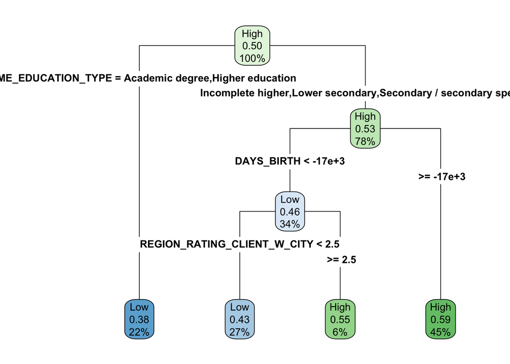

```r
#Classification tree
class_tr <- rpart(TARGET ~.,
                  data = train_df_rose, method = "class",
                  maxdepth = 30)
rpart.plot(class_tr, type = 4)
```

```r
#Predict training set
class_tr_train_predict <- predict(class_tr, train_df_rose,
                                  type = "class")

t(t(head(class_tr_train_predict,10)))
```

```
##    [,1]
## 1  High
## 2  Low
## 3  High
## 4  High
## 5  High
## 6  Low
## 7  Low
## 8  Low
## 9  High
## 10 Low
## Levels: Low High
```

```r
confusionMatrix(class_tr_train_predict, train_df_rose$TARGET, positive = "High")
```

```
## Confusion Matrix and Statistics
##
##           Reference
## Prediction  Low High
##       Low  6068 4223
##       High 4416 6290
##
##                Accuracy : 0.5886
##                  95% CI : (0.5819, 0.5952)
##     No Information Rate : 0.5007
##     P-Value [Acc > NIR] : < 2e-16
##
##                   Kappa : 0.1771
##
##  Mcnemar's Test P-Value : 0.03886
##
##             Sensitivity : 0.5983
##             Specificity : 0.5788
##          Pos Pred Value : 0.5875
##          Neg Pred Value : 0.5896
##              Prevalence : 0.5007
##          Detection Rate : 0.2996
##    Detection Prevalence : 0.5099
##       Balanced Accuracy : 0.5885
##
##        'Positive' Class : High
##
```

```r
#Predict validation set
class_tr_valid_predict <- predict(class_tr, valid_df,
                                  type = "class")

t(t(head(class_tr_valid_predict,10)))
```

```
##    [,1]
## 1  Low
## 2  Low
## 3  High
## 4  Low
## 5  Low
## 6  Low
## 7  Low
## 8  Low
## 9  Low
## 10 Low
## Levels: Low High
```

```r
confusionMatrix(class_tr_valid_predict, valid_df$TARGET, positive = "High")
```

```
## Confusion Matrix and Statistics
##
##           Reference
## Prediction  Low High
##       Low  4076  607
##       High 3219 1098
##
##                Accuracy : 0.5749
##                  95% CI : (0.5646, 0.5851)
##     No Information Rate : 0.8106
##     P-Value [Acc > NIR] : 1
##
##                   Kappa : 0.1277
##
##  Mcnemar's Test P-Value : <2e-16
##
##             Sensitivity : 0.6440
##             Specificity : 0.5587
##          Pos Pred Value : 0.2543
##          Neg Pred Value : 0.8704
##              Prevalence : 0.1894
##          Detection Rate : 0.1220
##    Detection Prevalence : 0.4797
##       Balanced Accuracy : 0.6014
##
##        'Positive' Class : High
##
```

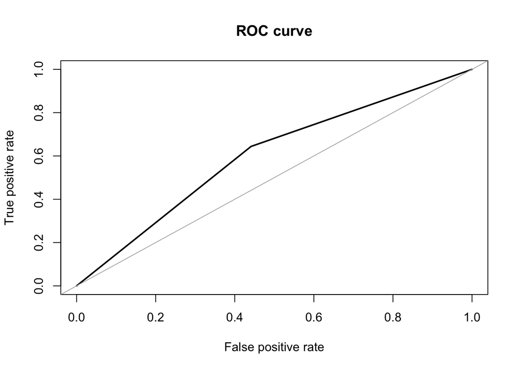

```
## Area under the curve (AUC): 0.601
```

```r
ROSE::roc.curve(valid_norm$TARGET, class_tr_valid_predict)
```

In this case, while the KNN models with k=3 and k=5 show higher accuracy on the training set, their accuracy drops considerably on the validation set, and they also have a low Kappa value, indicating they may not be reliable. The k=7 KNN model and the classification tree both show a similar pattern, although the classification tree seems to have less of a drop between training and validation accuracy. The classification tree also has a slightly higher balanced accuracy on the validation set than the KNN models, suggesting it might be more consistent across different levels of the outcome variable.

The classification tree model seems to be the best choice among the ones presented. It shows a less dramatic drop in accuracy between the training and validation sets compared to the KNN models, and it has the highest balanced accuracy in the validation set. This suggests it’s better at generalizing to new data, despite its overall lower accuracy compared to the KNN models on the training set. Applying this model to new applicants should efficiently identify high-risk individuals. With this early warning system, the financial institution can better manage credit risk exposure by tweaking loan offerings, interest rates, and mitigation tactics accordingly.

However, it’s important to note that even the best model here does not perform particularly well and the accuracy of this model is also not so high. The classification tree model demonstrates moderate predictive ability, with an accuracy slightly above the No Information Rate on the training set, suggesting it performs only marginally better than random chance. The Kappa statistic indicates minimal agreement, and the model’s balanced accuracy and AUC values point to a limited capacity to differentiate between ‘Low’ and ‘High’ risk classes. A slight decrease in accuracy on the validation set compared to the training set, along with a low Positive Predictive Value, signals potential overfitting, where the model fails to generalize well to new data.

Disparities in sensitivity and specificity across the training and validation sets reveal an imbalance in the model’s ability to correctly identify ‘High’ risk customers compared to ‘Low’ risk ones. While it predicts ‘Low’ risk with reasonable accuracy, indicated by a high Negative Predictive Value, it falls short in accurately predicting ‘High’ risk instances. These shortcomings highlight the need for further model improvement or considering different modeling approaches to achieve a more accurate and balanced predictive performance.

```r
#Use classification tree to predict the test set since it is the best model
predicted_credit_test <- predict(class_tr, newdata = credit_test_norm, type = "class")
predicted_credit_test
```

```
##    1    2    3    4    5
## High High  Low High High
## Levels: Low High
```

```r
#Probabilities
predicted_credit_test <- predict(class_tr, newdata = credit_test_norm, type = "prob")
predicted_credit_test
```

```
##         Low      High
## 1 0.4073007 0.5926993
## 2 0.4073007 0.5926993
## 3 0.6206593 0.3793407
## 4 0.4073007 0.5926993
## 5 0.4073007 0.5926993
```

Result: The classification tree model has been used to predict the credit risk for new customers, labeling each as ‘High’ or ‘Low’ risk based on the data. For the first five customers evaluated, the model predicts that customers 1, 2, 4, and 5 are of ‘High’ risk, while customer 3 is predicted to be ‘Low’ risk. These labels are determined by the model’s analysis of each customer’s features, learned during training, to recognize patterns associated with credit risk.

To complement these predictions, the model provides probabilities that indicate its confidence level. For instance, customer 1 has a 59.27% probability of being ‘High’ risk, suggesting moderate confidence in this prediction. In contrast, customer 3 has a 62.07% probability of being ‘Low’ risk, showing a stronger confidence in a lower risk of default. These probabilities offer Stark Enterprises a clearer perspective on the potential risk each new customer may carry, which is crucial for informed decision-making in their financial services.